# GDP Prediction

Nikhil Gupta

2020-02-21 05:20:09

# Setup

```r
library(tswge)
library(tidyverse)
library(tidyquant)
library(skimr)
library(plyr)
```

```r
library(ggplot2)
library(nnfor)  # Forecasting using Neural Networks
source("../misc_code_and_datasets/common_functions_tq.R")
```

```r
from = "1970-01-01"
```

# GDP Growth (Seasonally Adjusted)

```r
ID = "A191RP1Q027SBEA"
data = tqw_get_fred(ID = ID, from = from)
data %>% glimpse()
```

```
## Observations: 200
## Variables: 2
## $ date  <date> 1970-01-01, 1970-04-01, 1970-07-01, 1970-10-01, 1971-01...
## $ price <dbl> 5.1, 6.3, 7.2, 0.9, 18.2, 7.7, 7.6, 4.4, 14.3, 12.1, 7.9...
```

```r
data = data %>%
    tq_transmute(mutate_fun = to.period,
                 period = "quarters",
                 col_rename = "gdp_change")
data %>% glimpse()
```

```
## Observations: 200
## Variables: 2
## $ date       <date> 1970-01-01, 1970-04-01, 1970-07-01, 1970-10-01, 19...
## $ gdp_change <dbl> 5.1, 6.3, 7.2, 0.9, 18.2, 7.7, 7.6, 4.4, 14.3, 12.1...
```

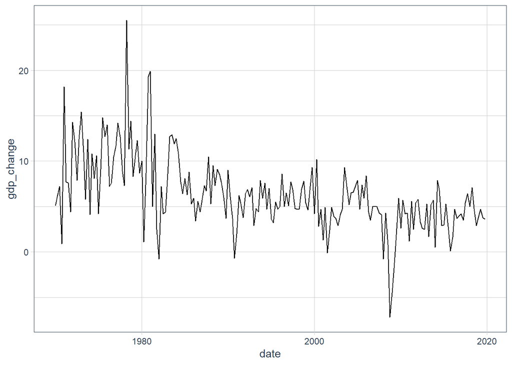

```r
data %>%
    ggplot(aes(x = date, y = gdp_change)) +
    geom_line() +
    #labs(title = title, y = y_label, x = x_label) +
    theme_tq()
```

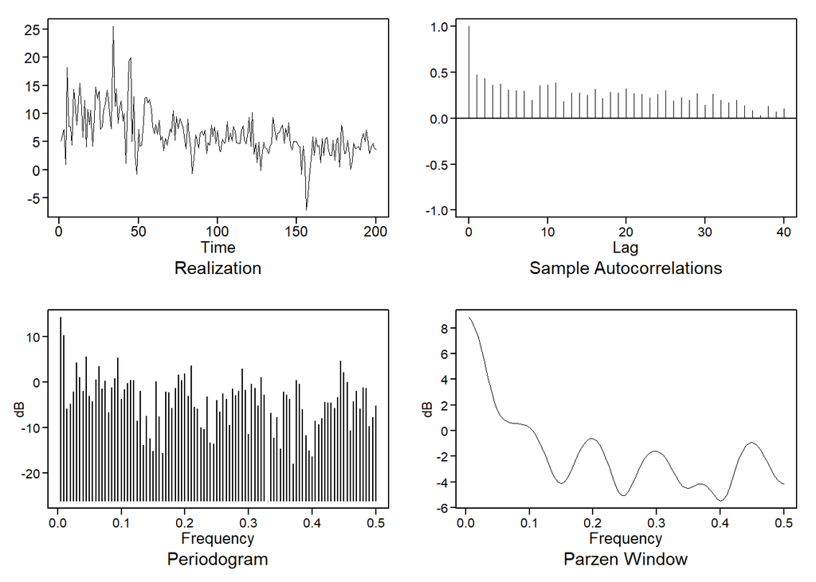

```r
px = plotts.sample.wge(data$gdp_change, lag.max = 40)
```

## Observations

- Looks like there are several peaks, but if we note carefully, the magnitude is less than 0.
- Peak at f = 0 is the most appreciable –> so this could come from an ARMA, ARIMA (no seasonality) or an ARIMA (with seasonality model)
- ACF’s have not died down even after lag of at least 32 (8 years!!) –> some indication of extended autocorrelations pointing to a ARIMA model (–> this is using older data)

Let’s see various fits to see.

## Fits

### Pure ARMA fit

```r
grid = aic5.wge(data$gdp_change)
```

```
## ---------WORKING... PLEASE WAIT...
##
##
## Five Smallest Values of  aic
```

```r
grid
```

```
##       p    q        aic
## 8     2    1   2.447386
## 11    3    1   2.447733
## 6     1    2   2.451552
## 5     1    1   2.454657
## 14    4    1   2.457517
```

```r
arma_fit = aic.wge(data$gdp_change)

factor.wge(phi = arma_fit$phi)
```

```
##
## Coefficients of Original polynomial:
## 1.1576 -0.1713
##
## Factor                 Roots                Abs Recip    System Freq
## 1-0.9833B              1.0170               0.9833       0.0000
## 1-0.1742B              5.7389               0.1742       0.0000
##
##
```

```r
factor.wge(phi = arma_fit$theta)
```

```
##
## Coefficients of Original polynomial:
## 0.8901
##
## Factor                 Roots                Abs Recip    System Freq
## 1-0.8901B              1.1235               0.8901       0.0000
##
##
```

#### Observations

- This solves a lot of the open questions
- The factor table for the fitted phi’s shows that the value of the dominant root is very close to 1 hence the realization is displaying ARIMA type of properties.

### ARIMA (no seasonality)

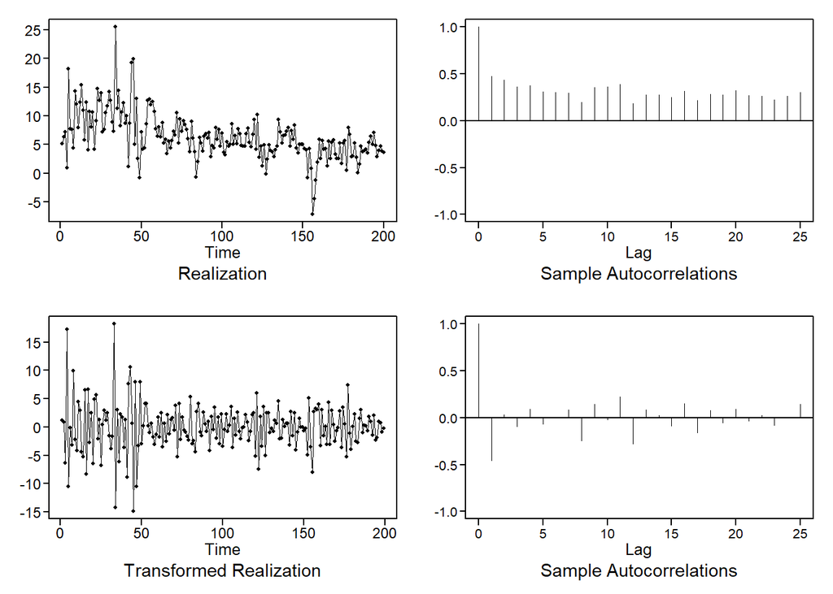

```r
results = tribble(~d, ~best_p, ~best_q, ~best_aic)


data_diff = artrans.wge(data$gdp_change, phi.tr = 1, plottr = TRUE)
```

```r
# px = plotts.sample.wge(data_no_season)
grid = aic5.wge(data_diff)
```

```
## ---------WORKING... PLEASE WAIT...
##
##
## Five Smallest Values of  aic
```

```r
best_aic = grid$`       aic`[1]
best_p = grid$`   p`[1]
best_q = grid$`   q`[1]

results = results %>%
  add_row(d = 1, best_p = best_p, best_q = best_q, best_aic = best_aic)

results %>%
  arrange(best_aic)
```

```
## # A tibble: 1 x 4
##       d best_p best_q best_aic
##   <dbl>  <dbl>  <dbl>    <dbl>
## 1     1      0      2     2.44
```

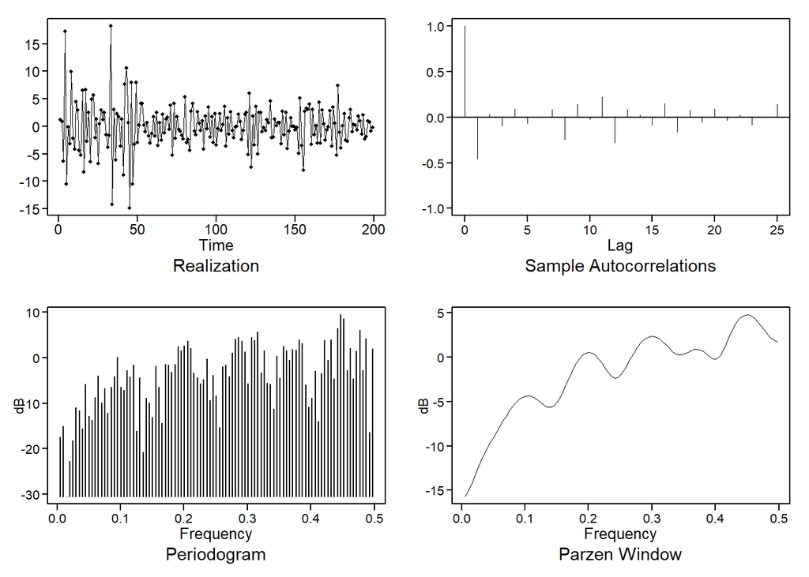

```r
px = plotts.sample.wge(data_diff)
```

```r
arima_fit = aic.wge(data_diff)

if (arima_fit$p != 0){ factor.wge(phi = arima_fit$phi)   }
if (arima_fit$q != 0){ factor.wge(phi = arima_fit$theta) }
```

```
##
## Coefficients of Original polynomial:
## 0.7690 0.1482
##
## Factor                 Roots                Abs Recip    System Freq
## 1-0.9286B              1.0769               0.9286       0.0000
## 1+0.1596B             -6.2649               0.1596       0.5000
##
##
```

#### Observations

- Best AIC is for ARIMA(0,1,2) with s = 0.
- Best AIC = 2.444 which is very close to the pure ARMA model since that has a dominant root very close to 1 anyway.

### ARIMA with d = 0 and Seasonality != 0

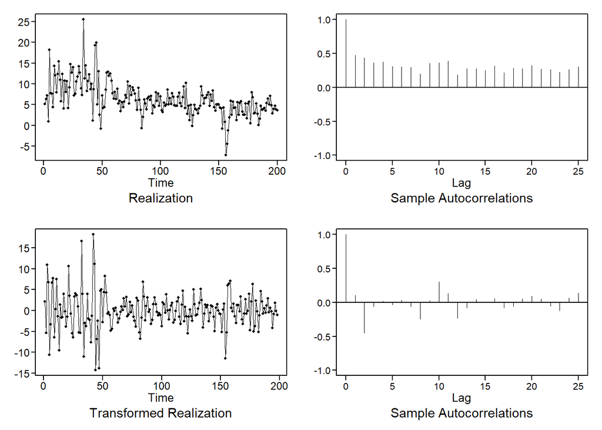

```
## ---------WORKING... PLEASE WAIT...
##
##
## Five Smallest Values of  aic
```

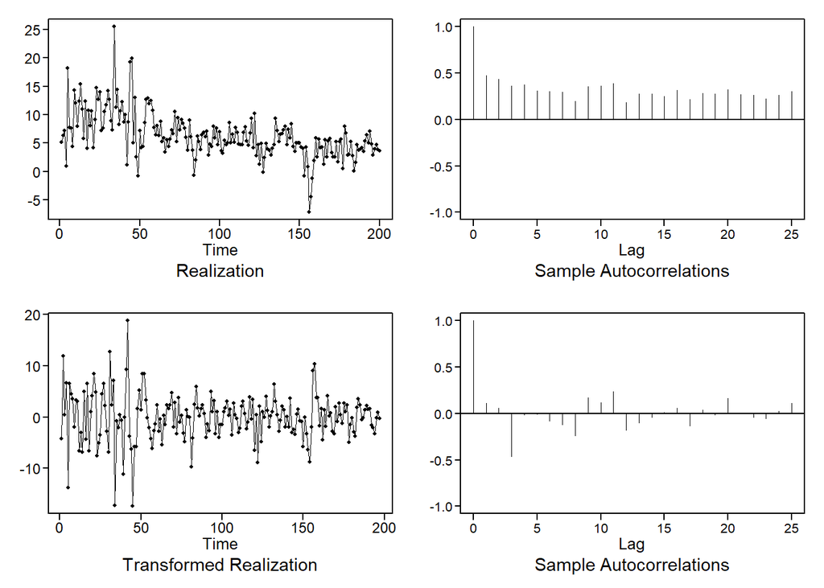

```
## ---------WORKING... PLEASE WAIT...
##
##
## Five Smallest Values of  aic
```

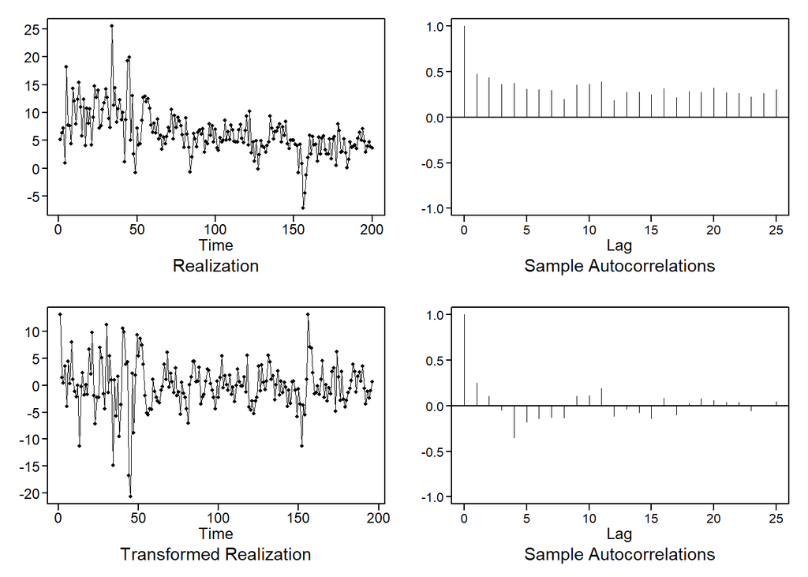

```
## ---------WORKING... PLEASE WAIT...
##
##
## Five Smallest Values of  aic
```

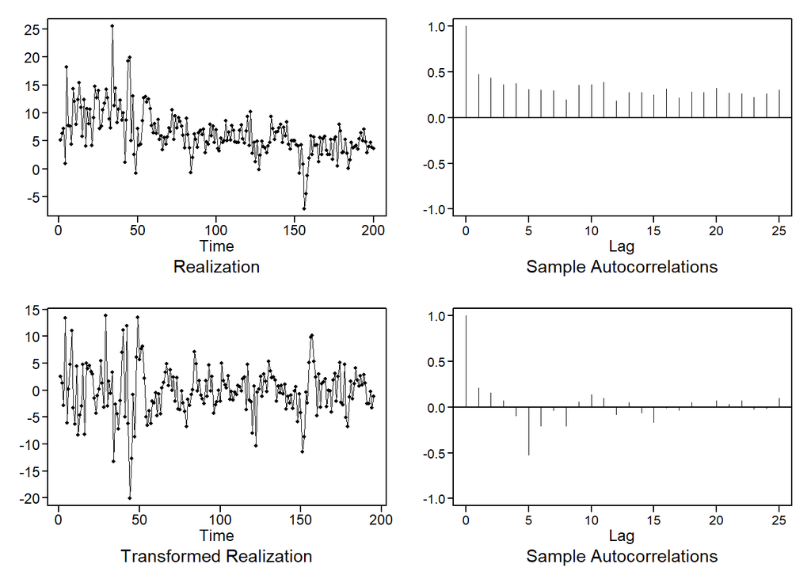

```
## ---------WORKING... PLEASE WAIT...
##
##
## Five Smallest Values of  aic
```

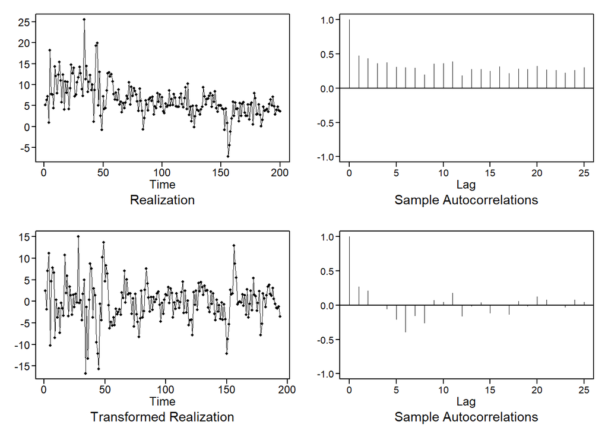

```
## ---------WORKING... PLEASE WAIT...
##
##
## Five Smallest Values of  aic
```

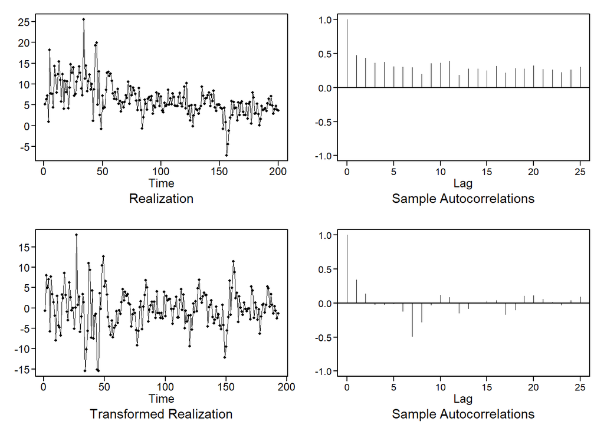

```
## ---------WORKING... PLEASE WAIT...
##
##
## Five Smallest Values of  aic
```

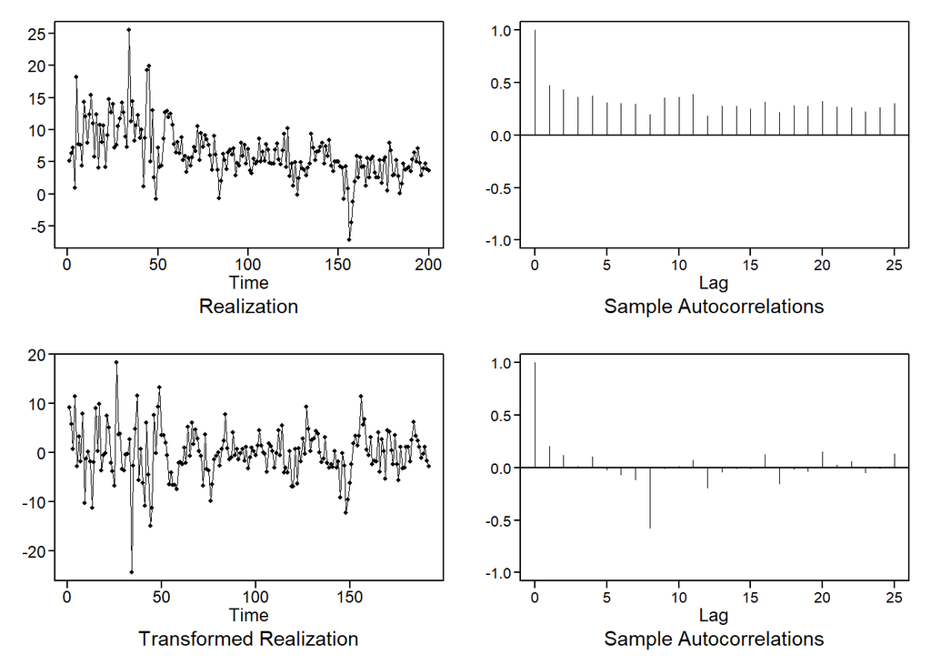

```
## ---------WORKING... PLEASE WAIT...
##
##
## Five Smallest Values of  aic
```

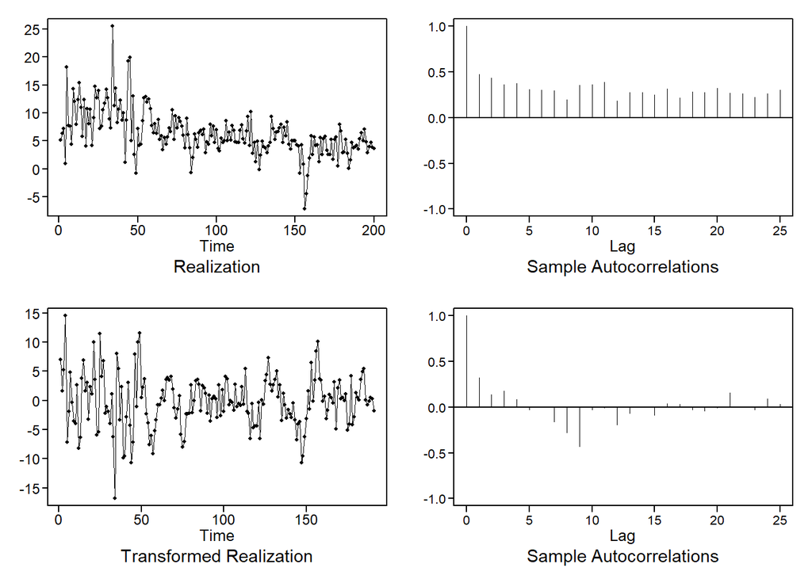

```
## ---------WORKING... PLEASE WAIT...
##
##
## Five Smallest Values of  aic
```

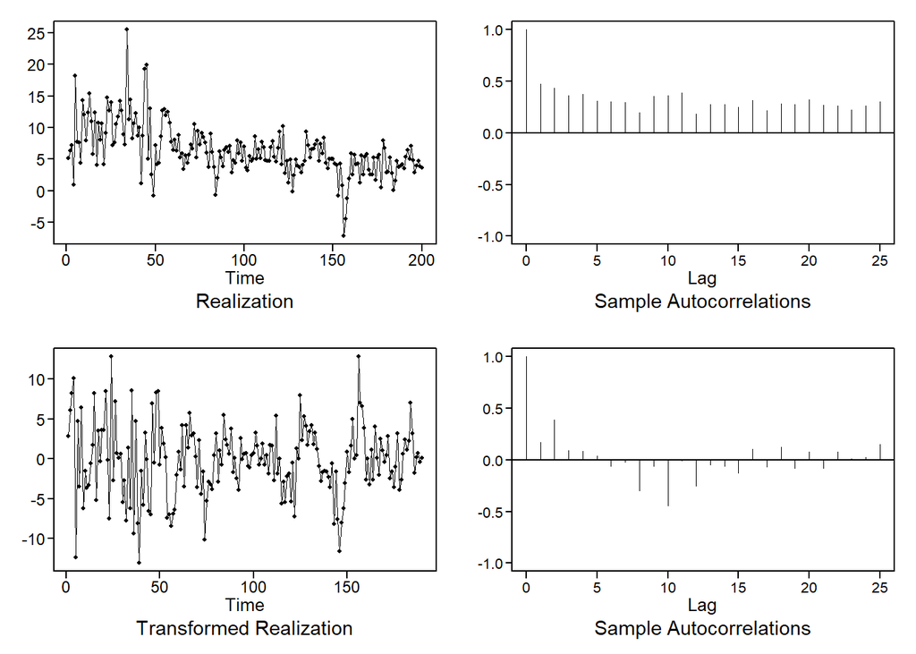

```
## ---------WORKING... PLEASE WAIT...
##
##
## Five Smallest Values of  aic
```

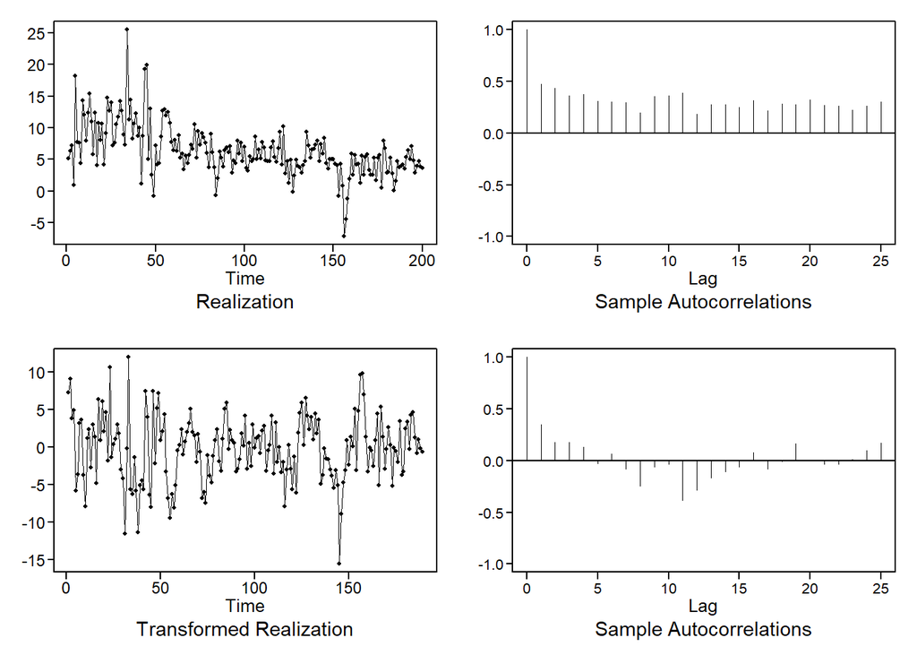

```
## ---------WORKING... PLEASE WAIT...
##
##
## Five Smallest Values of  aic
```

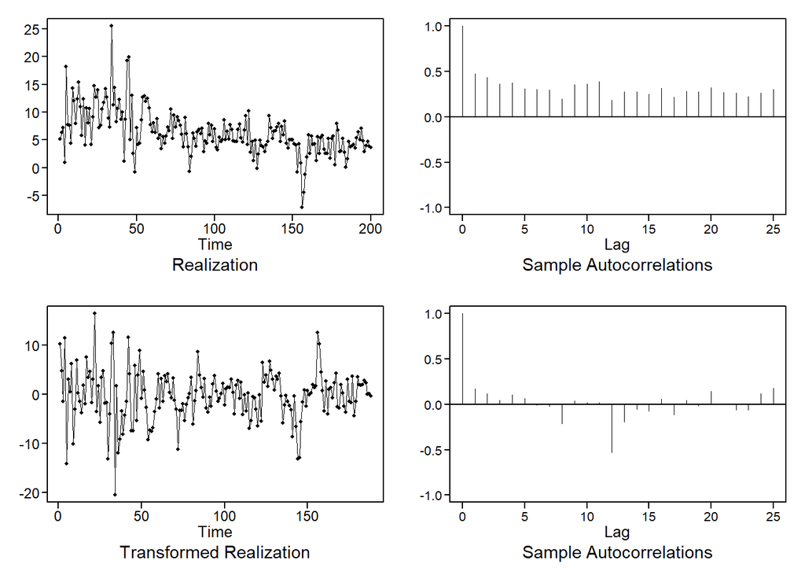

```
## ---------WORKING... PLEASE WAIT...
##
##
## Five Smallest Values of  aic
```

```r
results = tribble(~seasonality, ~best_p, ~best_q, ~best_aic)

for (s in 2:12){
  # Note when s = 1, this returns a ARIMA model with d = 1 and no seasonality
  # For s > 1, this returns a ARIMA model with d = 0 and seasonality = s
  data_no_season = artrans.wge(data$gdp_change, phi.tr = c(rep(0, s-1),1), plottr = TRUE)
  # px = plotts.sample.wge(data_no_season)
  grid = aic5.wge(data_no_season)
  best_aic = grid$`       aic`[1]
  best_p = grid$`   p`[1]
  best_q = grid$`   q`[1]

  results = results %>%
    add_row(seasonality = s, best_p = best_p, best_q = best_q, best_aic = best_aic)
}
```

```r
results %>%
  arrange(best_aic)
```

```
## # A tibble: 11 x 4
##    seasonality best_p best_q best_aic
##          <int>  <dbl>  <dbl>    <dbl>
##  1           2      5      2     2.54
##  2           5      5      2     2.66
##  3           3      5      1     2.71
##  4          10      4      1     2.75
##  5          11      4      2     2.77
##  6           9      3      2     2.86
##  7           4      4      0     2.87
##  8           7      2      2     2.91
##  9           6      5      1     2.97
## 10           8      2      2     3.19
## 11          12      3      1     3.21
```

#### Observations

- Best Model including Seasonality is ARIMA(5,0,2) with s = 2
- However, this is not as good as the pure ARMA model or the ARIMA with no seasonality model.
- We will exclude this from the final consideration.

## Predictions

```r
n.ahead = 4

compute_ase = function(data, forecast, n.ahead){
  n = length(data)
  ase = mean((data[(n-n.ahead+1):n] - forecast$f)^2)
  return(ase)
}

results = tribble(~model, ~ase)
```

### Pure ARMA

```r
model = "ARMA"
fore_arma = fore.arma.wge(data$gdp_change, phi = arma_fit$phi, theta = arma_fit$theta, n.ahead = n.ahead, lastn = TRUE)
```

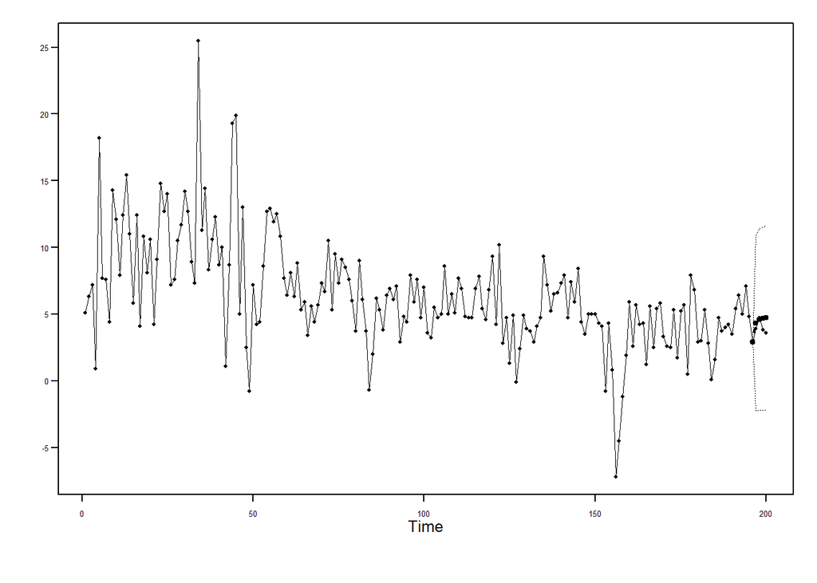

```r
ase_arma = compute_ase(data = data$gdp_change, forecast = fore_arma, n.ahead = n.ahead)

results = results %>%
    add_row(model = model, ase = ase_arma)
```

### ARIMA()

```r
model = "ARIMA"
fore_arima = fore.aruma.wge(data$gdp_change, phi = arima_fit$phi, theta = arima_fit$theta, n.ahead = n.ahead, lastn = TRUE)
```

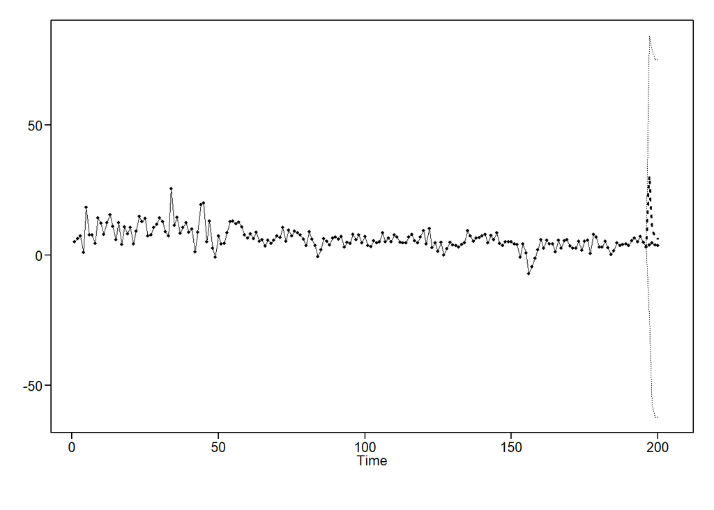

```r
ase_arima = compute_ase(data = data$gdp_change, forecast = fore_arima, n.ahead = n.ahead)

results = results %>%
    add_row(model = model, ase = ase_arima)
```

```r
results
```

```
## # A tibble: 2 x 2
##   model     ase
##   <chr>   <dbl>
## 1 ARMA    0.547
## 2 ARIMA 185.
```

# Conclusion

- ARMA(2,1) and ARIMA(0,1,2) seem to give similar results based on AIC
- However, ARIMA fails terribly at predicton and the ASE is huge especially for immediate predictons.
- Hence we would recommend using the ARMA model in this case.
- This model only takes ‘time’ into consideration while building the model. There may be other exogenous variables that may impact GDP which we have not considered at all. We will do that next with VAR models and Neural Networks.

# Collecting more correlated data

```r
aggregate.period = "quarters"
index.at = "yearqtr"
from = "1900-01-01"  ## Going to increase the horizon since we need more data for NN models
```

## GDP

```r
ID = "A191RP1Q027SBEA"

gdp_change = tqw_get_fred(ID = ID, from = from)
gdp_change %>% glimpse()
```

```
## Observations: 291
## Variables: 2
## $ date  <date> 1947-04-01, 1947-07-01, 1947-10-01, 1948-01-01, 1948-04...
## $ price <dbl> 4.7, 6.0, 17.3, 9.6, 10.7, 10.1, 1.7, -7.4, -5.2, 2.3, -...
```

```r
gdp_change = gdp_change %>%
    tq_transmute(mutate_fun = to.period,
                 period = aggregate.period,
                 indexAt = index.at,
                 col_rename = "gdp_change")

gdp_change %>% glimpse()
```

```
## Observations: 291
## Variables: 2
## $ date       <yearqtr> 1947 Q2, 1947 Q3, 1947 Q4, 1948 Q1, 1948 Q2, 19...
## $ gdp_change <dbl> 4.7, 6.0, 17.3, 9.6, 10.7, 10.1, 1.7, -7.4, -5.2, 2...
```

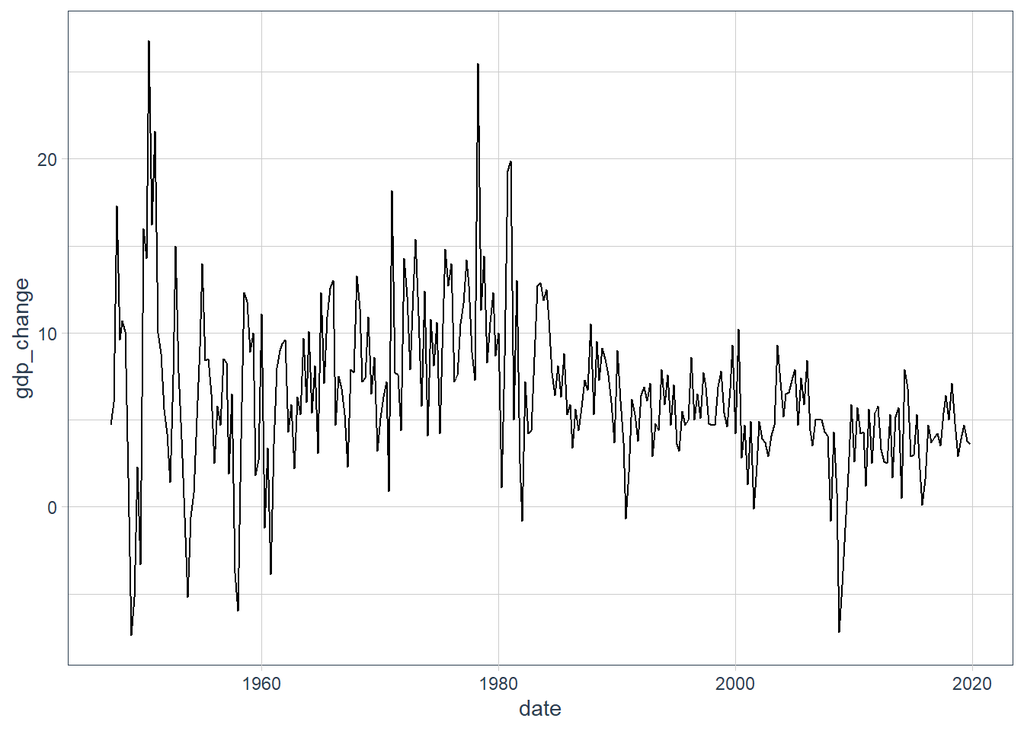

```r
gdp_change %>%
    ggplot(aes(x = date, y = gdp_change)) +
    geom_line() +
    #labs(title = title, y = y_label, x = x_label) +
    theme_tq()
```

## LABOR MARKET

### Unemployment Rate

```r
ID = "UNRATE"

unrate = tqw_get_fred(ID = ID, from = from)
unrate %>% glimpse()
```

```
## Observations: 865
## Variables: 2
## $ date  <date> 1948-01-01, 1948-02-01, 1948-03-01, 1948-04-01, 1948-05...
## $ price <dbl> 3.4, 3.8, 4.0, 3.9, 3.5, 3.6, 3.6, 3.9, 3.8, 3.7, 3.8, 4...
```

```r
unrate = unrate %>%
    tq_transmute(mutate_fun = to.period,
                 period = aggregate.period,
                 indexAt = index.at,
                 col_rename = "unrate")

unrate %>% glimpse()
```

```
## Observations: 289
## Variables: 2
## $ date   <yearqtr> 1948 Q1, 1948 Q2, 1948 Q3, 1948 Q4, 1949 Q1, 1949 Q...
## $ unrate <dbl> 4.0, 3.6, 3.8, 4.0, 5.0, 6.2, 6.6, 6.6, 6.3, 5.4, 4.4, ...
```

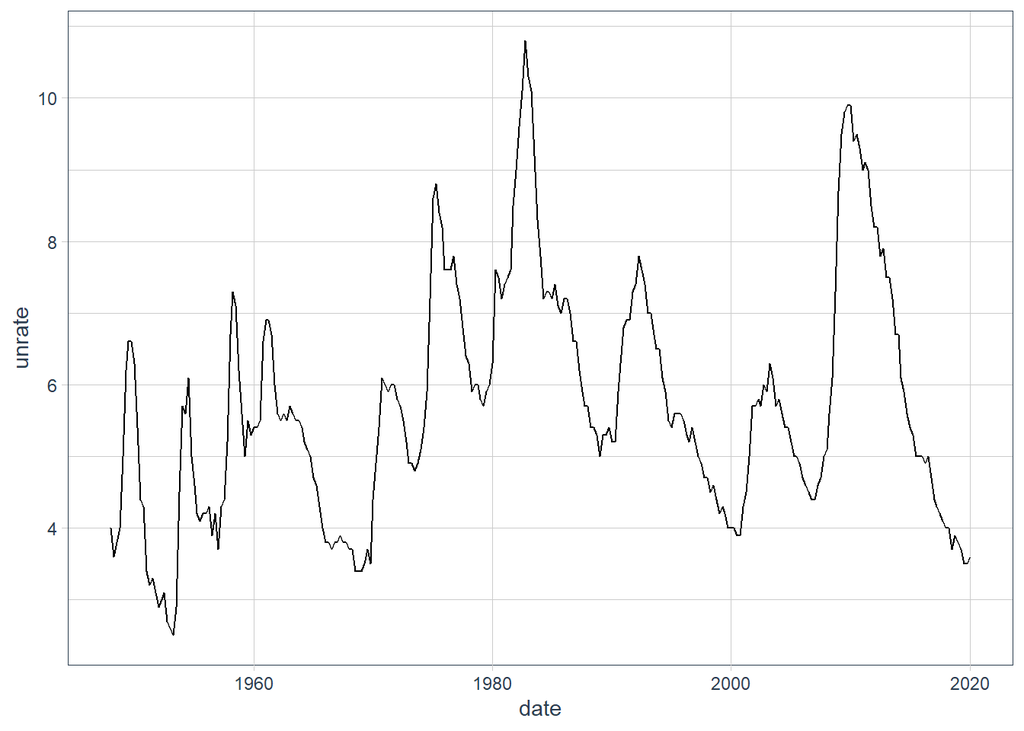

```r
unrate %>%
    ggplot(aes(x = date, y = unrate)) +
    geom_line() +
    #labs(title = title, y = y_label, x = x_label) +
    theme_tq()
```

### Non Farm Jobs (Seasonally Adjusted)

```r
ID = "PAYEMS"

nfjobs = tqw_get_fred(ID = ID, from = from)
nfjobs %>% glimpse()
```

```
## Observations: 973
## Variables: 2
## $ date  <date> 1939-01-01, 1939-02-01, 1939-03-01, 1939-04-01, 1939-05...
## $ price <int> 29923, 30100, 30280, 30094, 30299, 30502, 30419, 30663, ...
```

```r
nfjobs = nfjobs %>%
    tq_transmute(mutate_fun = to.period,
                 period = aggregate.period,
                 indexAt = index.at,
                 col_rename = "nfjobs")

nfjobs %>% glimpse()
```

```
## Observations: 325
## Variables: 2
## $ date   <yearqtr> 1939 Q1, 1939 Q2, 1939 Q3, 1939 Q4, 1940 Q1, 1940 Q...
## $ nfjobs <int> 30280, 30502, 31031, 31542, 31825, 31977, 32810, 34174,...
```

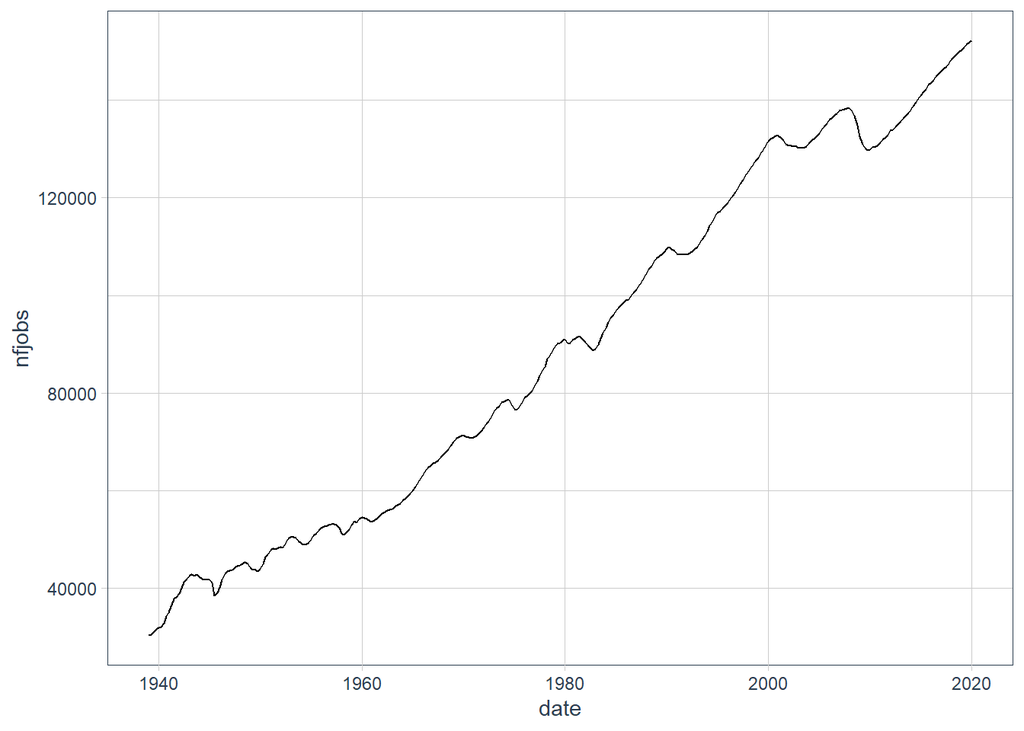

```r
nfjobs %>%
    ggplot(aes(x = date, y = nfjobs)) +
    geom_line() +
    #labs(title = title, y = y_label, x = x_label) +
    theme_tq()
```

## MONITORY POLICY

### 10 yr Treasury Rate

```r
ID = "DGS10"

treas10yr = tqw_get_fred(ID = ID, from = from)
treas10yr %>% glimpse()
```

```
## Observations: 15,167
## Variables: 2
## $ date  <date> 1962-01-02, 1962-01-03, 1962-01-04, 1962-01-05, 1962-01...
## $ price <dbl> 4.06, 4.03, 3.99, 4.02, 4.03, 4.05, 4.07, 4.08, 4.08, 4....
```

```r
treas10yr %>% skim()  # Few missing values
```

```
## Skim summary statistics
##  n obs: 15167
##  n variables: 2
##
## -- Variable type:Date -----------------------------------------------------------------------------------------------------------------
##  variable missing complete     n        min        max     median n_unique
##      date       0    15167 15167 1962-01-02 2020-02-19 1991-01-25    15167
##
## -- Variable type:numeric --------------------------------------------------------------------------------------------------------------
##  variable missing complete     n mean  sd   p0  p25  p50  p75  p100
##     price     650    14517 15167 6.11 2.9 1.37 4.03 5.87 7.78 15.84
##      hist
##  ▆▇▇▇▂▂▁▁
```

```r
treas10yr = treas10yr %>%
    tq_transmute(mutate_fun = to.period,
                 period = aggregate.period,
                 indexAt = index.at,
                 col_rename = "treas10yr")
treas10yr %>% glimpse()
```

```
## Observations: 233
## Variables: 2
## $ date      <yearqtr> 1962 Q1, 1962 Q2, 1962 Q3, 1962 Q4, 1963 Q1, 196...
## $ treas10yr <dbl> 3.86, 4.00, 3.94, 3.85, 3.95, 4.00, 4.07, 4.14, 4.23...
```

```r
# treas10yr %>% skim() # No missing values
```

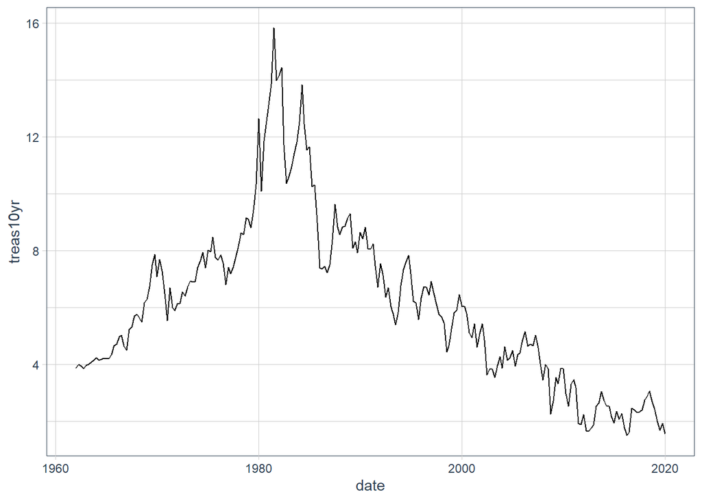

```r
treas10yr %>%
    ggplot(aes(x = date, y = treas10yr)) +
    geom_line() +
    #labs(title = title, y = y_label, x = x_label) +
    theme_tq()
```

### 3 mo Treasury Rate

```r
ID = "DGS3MO"

treas3mo = tqw_get_fred(ID = ID, from = from)
treas3mo %>% glimpse()
```

```
## Observations: 9,948
## Variables: 2
## $ date  <date> 1982-01-04, 1982-01-05, 1982-01-06, 1982-01-07, 1982-01...
## $ price <dbl> 11.87, 12.20, 12.16, 12.17, 11.98, 12.49, 12.52, 12.70, ...
```

```r
treas3mo = treas3mo %>%
    tq_transmute(mutate_fun = to.period,
                 period = aggregate.period,
                 indexAt = index.at,
                 col_rename = "treas3mo")
treas3mo %>% glimpse()
```

```
## Observations: 153
## Variables: 2
## $ date     <yearqtr> 1982 Q1, 1982 Q2, 1982 Q3, 1982 Q4, 1983 Q1, 1983...
## $ treas3mo <dbl> 13.99, 13.36, 7.88, 8.20, 8.96, 9.15, 9.04, 9.33, 10....
```

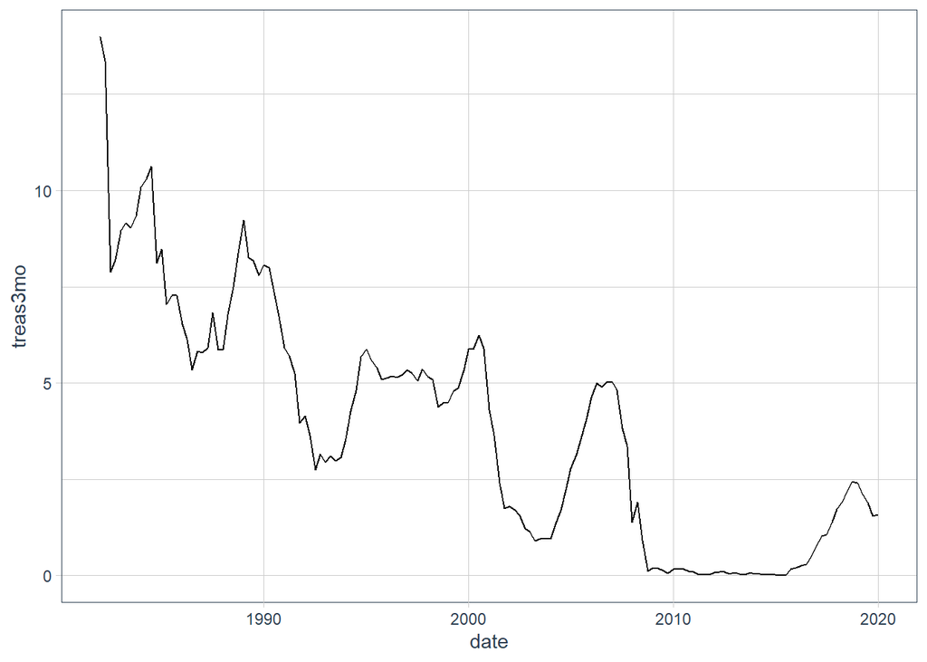

```r
treas3mo %>%
    ggplot(aes(x = date, y = treas3mo)) +
    geom_line() +
    #labs(title = title, y = y_label, x = x_label) +
    theme_tq()
```

### 10yr - 3mo Treasury

```r
ID = "T10Y3M"

treas10yr3mo = tqw_get_fred(ID = ID, from = from)
treas10yr3mo %>% glimpse()
```

```
## Observations: 9,949
## Variables: 2
## $ date  <date> 1982-01-04, 1982-01-05, 1982-01-06, 1982-01-07, 1982-01...
## $ price <dbl> 2.32, 2.24, 2.43, 2.46, 2.50, 2.32, 2.10, 2.13, 1.53, 2....
```

```r
treas10yr3mo = treas10yr3mo %>%
    tq_transmute(mutate_fun = to.period,
                 period = aggregate.period,
                 indexAt = index.at,
                 col_rename = "treas10yr3mo")
treas10yr3mo %>% glimpse()
```

```
## Observations: 153
## Variables: 2
## $ date         <yearqtr> 1982 Q1, 1982 Q2, 1982 Q3, 1982 Q4, 1983 Q1, ...
## $ treas10yr3mo <dbl> 0.19, 1.08, 3.85, 2.16, 1.66, 1.81, 2.40, 2.49, 2...
```

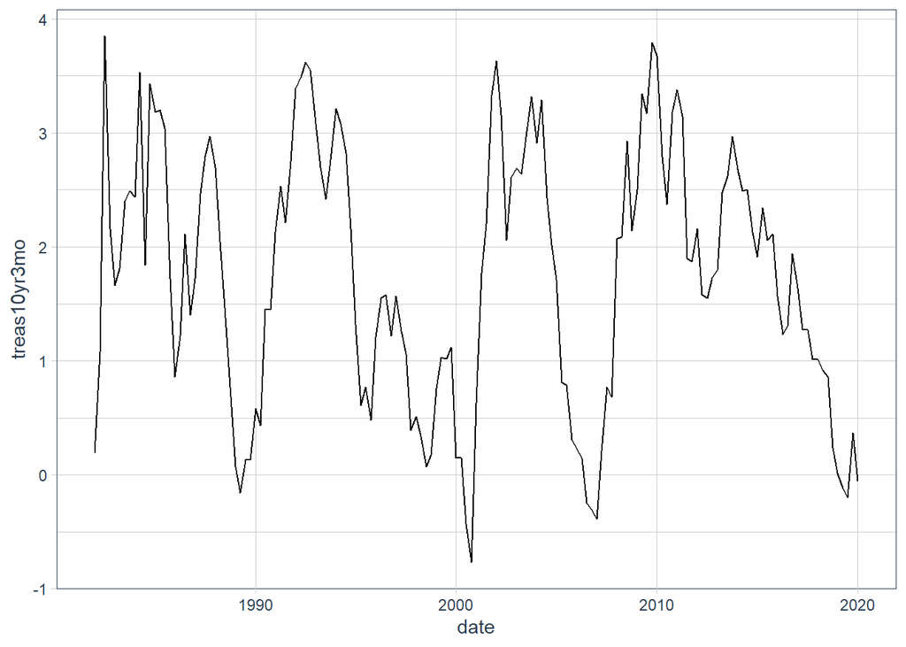

```r
treas10yr3mo %>%
    ggplot(aes(x = date, y = treas10yr3mo)) +
    geom_line() +
    #labs(title = title, y = y_label, x = x_label) +
    theme_tq()
```

### Federal Funds Interest Rate

```r
ID = "FEDFUNDS"

fedintrate = tqw_get_fred(ID = ID, from = from)
fedintrate %>% glimpse()
```

```
## Observations: 787
## Variables: 2
## $ date  <date> 1954-07-01, 1954-08-01, 1954-09-01, 1954-10-01, 1954-11...
## $ price <dbl> 0.80, 1.22, 1.06, 0.85, 0.83, 1.28, 1.39, 1.29, 1.35, 1....
```

```r
fedintrate = fedintrate %>%
    tq_transmute(mutate_fun = to.period,
                 period = aggregate.period,
                 indexAt = index.at,
                 col_rename = "fedintrate")

fedintrate %>% glimpse()
```

```
## Observations: 263
## Variables: 2
## $ date       <yearqtr> 1954 Q3, 1954 Q4, 1955 Q1, 1955 Q2, 1955 Q3, 19...
## $ fedintrate <dbl> 1.06, 1.28, 1.35, 1.64, 2.18, 2.48, 2.50, 2.71, 2.9...
```

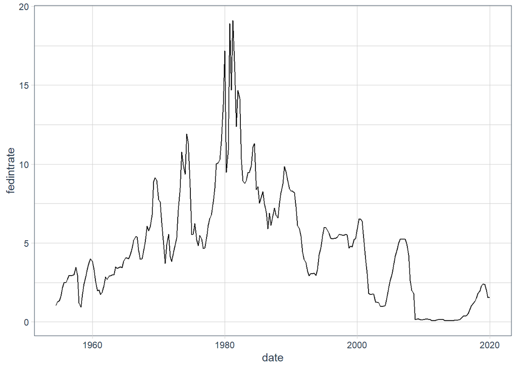

```r
fedintrate %>%
    ggplot(aes(x = date, y = fedintrate)) +
    geom_line() +
    #labs(title = title, y = y_label, x = x_label) +
    theme_tq()
```

### 3 month LIBOR

```r
ID = "USD3MTD156N"

libor3mo = tqw_get_fred(ID = ID, from = from)
libor3mo %>% glimpse()
```

```
## Observations: 8,901
## Variables: 2
## $ date  <date> 1986-01-02, 1986-01-03, 1986-01-06, 1986-01-07, 1986-01...
## $ price <dbl> 8.0000, 8.0625, 8.1250, 8.1250, 8.0000, 8.1875, 8.2500, ...
```

```r
libor3mo = libor3mo %>%
    tq_transmute(mutate_fun = to.period,
                 period = aggregate.period,
                 indexAt = index.at,
                 col_rename = "libor3mo")
libor3mo %>% glimpse()
```

```
## Observations: 137
## Variables: 2
## $ date     <yearqtr> 1986 Q1, 1986 Q2, 1986 Q3, 1986 Q4, 1987 Q1, 1987...
## $ libor3mo <dbl> 7.43750, 6.87500, 6.12500, 6.43750, 6.68750, 7.18750,...
```

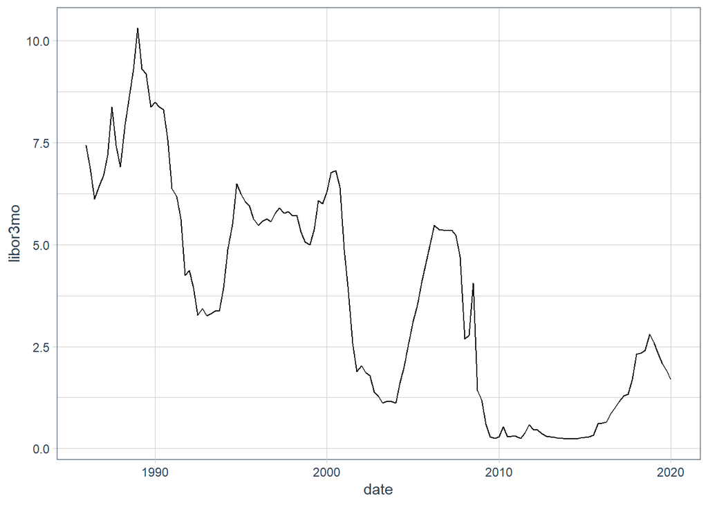

```r
libor3mo %>%
    ggplot(aes(x = date, y = libor3mo)) +
    geom_line() +
    #labs(title = title, y = y_label, x = x_label) +
    theme_tq()
```

## CONSUMER RELATED

### Real Disposable Personal Income Change

```r
ID = "A067RO1Q156NBEA"

personincomechg = tqw_get_fred(ID = ID, from = from)
personincomechg %>% glimpse()
```

```
## Observations: 288
## Variables: 2
## $ date  <date> 1948-01-01, 1948-04-01, 1948-07-01, 1948-10-01, 1949-01...
## $ price <dbl> 2.1, 6.3, 5.2, 7.3, 3.3, 0.7, -0.3, -0.3, 9.6, 8.7, 9.4,...
```

```r
personincomechg = personincomechg %>%
    tq_transmute(mutate_fun = to.period,
                 period = aggregate.period,
                 indexAt = index.at,
                 col_rename = "personincomechg")

personincomechg %>% glimpse()
```

```
## Observations: 288
## Variables: 2
## $ date            <yearqtr> 1948 Q1, 1948 Q2, 1948 Q3, 1948 Q4, 1949 Q...
## $ personincomechg <dbl> 2.1, 6.3, 5.2, 7.3, 3.3, 0.7, -0.3, -0.3, 9.6,...
```

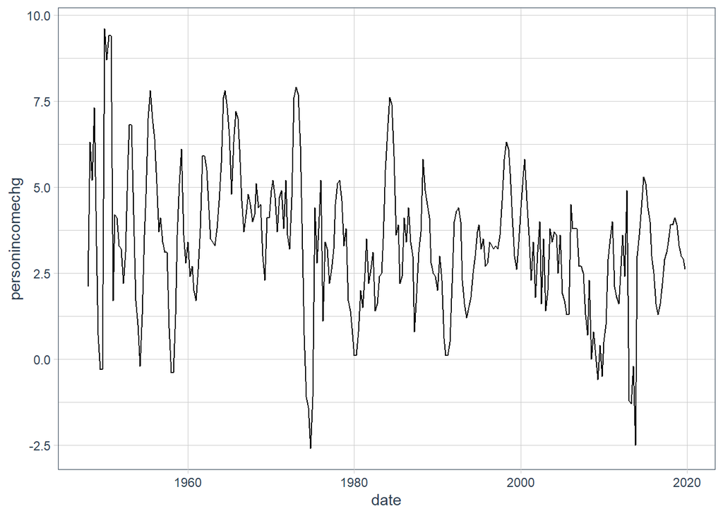

```r
personincomechg %>%
    ggplot(aes(x = date, y = personincomechg)) +
    geom_line() +
    #labs(title = title, y = y_label, x = x_label) +
    theme_tq()
```

### Consumer Price Index (inflation)

```r
ID = "CPIAUCNS"

cpi = tqw_get_fred(ID = ID, from = from)
cpi %>% glimpse()
```

```
## Observations: 1,285
## Variables: 2
## $ date  <date> 1913-01-01, 1913-02-01, 1913-03-01, 1913-04-01, 1913-05...
## $ price <dbl> 9.8, 9.8, 9.8, 9.8, 9.7, 9.8, 9.9, 9.9, 10.0, 10.0, 10.1...
```

```r
cpi = cpi %>%
    tq_transmute(mutate_fun = to.period,
                 period = aggregate.period,
                 indexAt = index.at,
                 col_rename = "cpi")

cpi %>% glimpse()
```

```
## Observations: 429
## Variables: 2
## $ date <yearqtr> 1913 Q1, 1913 Q2, 1913 Q3, 1913 Q4, 1914 Q1, 1914 Q2,...
## $ cpi  <dbl> 9.8, 9.8, 10.0, 10.0, 9.9, 9.9, 10.2, 10.1, 9.9, 10.1, 10...
```

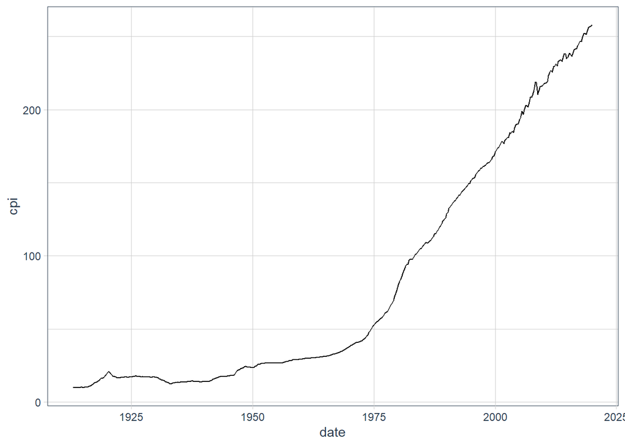

```r
cpi %>%
    ggplot(aes(x = date, y = cpi)) +
    geom_line() +
    #labs(title = title, y = y_label, x = x_label) +
    theme_tq()
```

### Population

```r
ID = "POPTHM"

population = tqw_get_fred(ID = ID, from = from)
population %>% glimpse()
```

```
## Observations: 732
## Variables: 2
## $ date  <date> 1959-01-01, 1959-02-01, 1959-03-01, 1959-04-01, 1959-05...
## $ price <int> 175818, 176044, 176274, 176503, 176723, 176954, 177208, ...
```

```r
population = population %>%
    tq_transmute(mutate_fun = to.period,
                 period = aggregate.period,
                 indexAt = index.at,
                 col_rename = "population")

population %>% glimpse()
```

```
## Observations: 244
## Variables: 2
## $ date       <yearqtr> 1959 Q1, 1959 Q2, 1959 Q3, 1959 Q4, 1960 Q1, 19...
## $ population <int> 176274, 176954, 177755, 178504, 179707, 180728, 181...
```

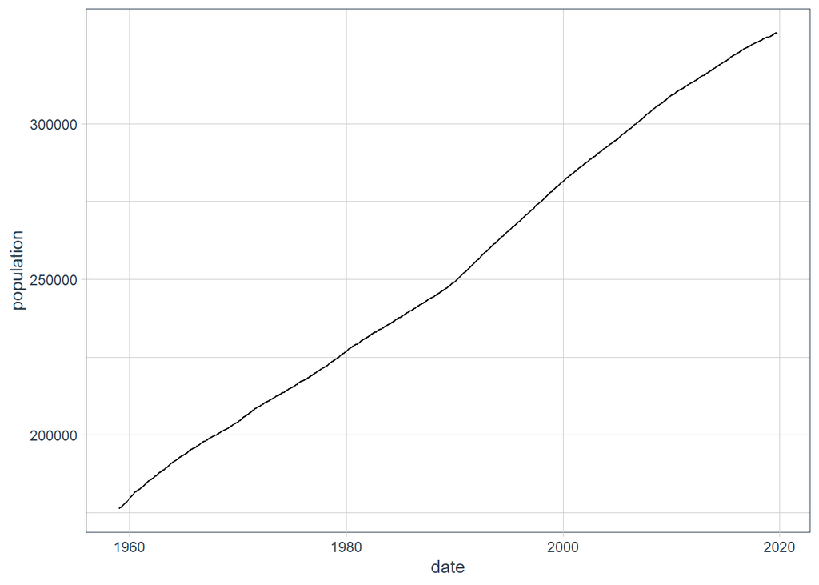

```r
population %>%
    ggplot(aes(x = date, y = population)) +
    geom_line() +
    #labs(title = title, y = y_label, x = x_label) +
    theme_tq()
```

## BUSINESS ENVIRONMENT

### Corporate Profits

```r
ID = "CP"

corpprofit = tqw_get_fred(ID = ID, from = from)
corpprofit %>% glimpse()
```

```
## Observations: 291
## Variables: 2
## $ date  <date> 1947-01-01, 1947-04-01, 1947-07-01, 1947-10-01, 1948-01...
## $ price <dbl> 21.970, 20.788, 20.564, 22.451, 23.739, 24.941, 24.551, ...
```

```r
corpprofitchg = corpprofit %>%
  tq_transmute(mutate_fun = periodReturn,  # Note this is different from others as I am converting raw values to % changes
                 period = "quarterly",
                 col_rename = "corpprofitchg") %>%
  mutate(corpprofitchg = corpprofitchg * 100) %>%
  tq_transmute(mutate_fun = to.period,
                 period = aggregate.period,
                 indexAt = index.at,
                 col_rename = "corpprofitchg")

corpprofitchg %>% glimpse()
```

```
## Observations: 291
## Variables: 2
## $ date          <yearqtr> 1947 Q1, 1947 Q2, 1947 Q3, 1947 Q4, 1948 Q1,...
## $ corpprofitchg <dbl> 0.000000, -5.380064, -1.077545, 9.176230, 5.7369...
```

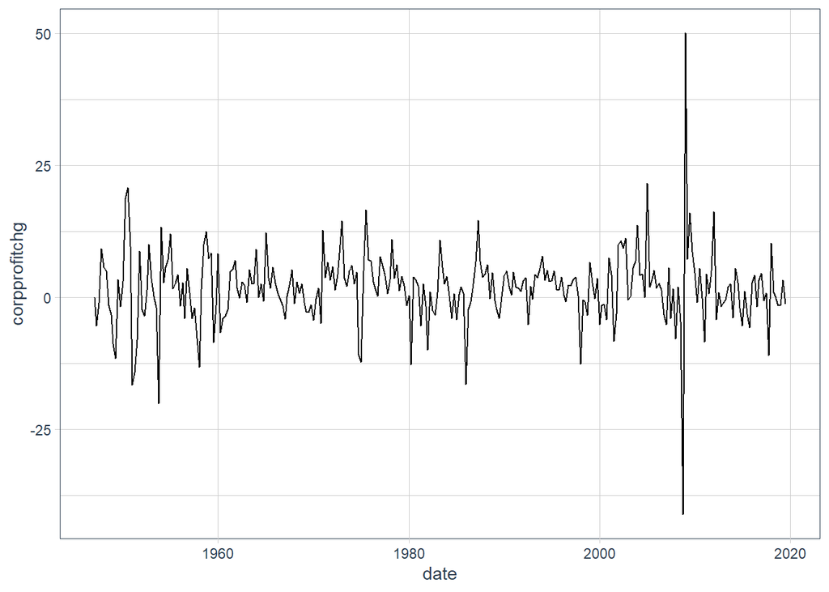

```r
corpprofitchg %>%
    ggplot(aes(x = date, y = corpprofitchg)) +
    geom_line() +
    #labs(title = title, y = y_label, x = x_label) +
    theme_tq()
```

### Crude Oil

```r
ID = "WTISPLC"

crude_wti = tqw_get_fred(ID = ID, from = from)
crude_wti %>% glimpse()
```

```
## Observations: 889
## Variables: 2
## $ date  <date> 1946-01-01, 1946-02-01, 1946-03-01, 1946-04-01, 1946-05...
## $ price <dbl> 1.17, 1.17, 1.17, 1.27, 1.27, 1.27, 1.27, 1.52, 1.52, 1....
```

```r
crude_wti = crude_wti %>%
    tq_transmute(mutate_fun = to.period,
                 period = aggregate.period,
                 indexAt = index.at,
                 col_rename = "crude_wti")

crude_wti %>% glimpse()
```

```
## Observations: 297
## Variables: 2
## $ date      <yearqtr> 1946 Q1, 1946 Q2, 1946 Q3, 1946 Q4, 1947 Q1, 194...
## $ crude_wti <dbl> 1.17, 1.27, 1.52, 1.62, 1.62, 1.87, 1.87, 2.07, 2.57...
```

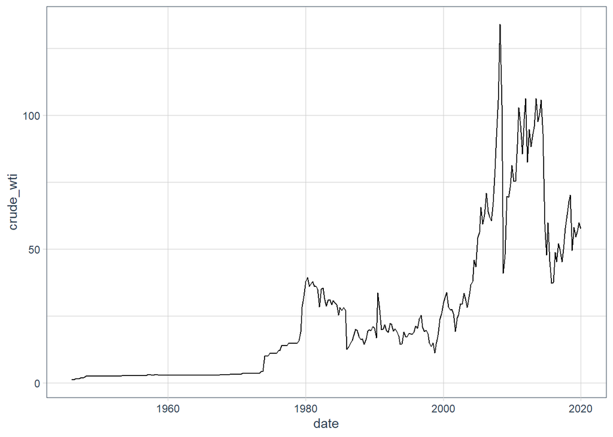

```r
crude_wti %>%
    ggplot(aes(x = date, y = crude_wti)) +
    geom_line() +
    #labs(title = title, y = y_label, x = x_label) +
    theme_tq()
```

### Producer Price Index

```r
ID = "PPIACO"

ppi = tqw_get_fred(ID = ID, from = from)
ppi %>% glimpse()
```

```
## Observations: 1,285
## Variables: 2
## $ date  <date> 1913-01-01, 1913-02-01, 1913-03-01, 1913-04-01, 1913-05...
## $ price <dbl> 12.1, 12.0, 12.0, 12.0, 11.9, 11.9, 12.0, 12.0, 12.2, 12...
```

```r
ppi = ppi %>%
    tq_transmute(mutate_fun = to.period,
                 period = aggregate.period,
                 indexAt = index.at,
                 col_rename = "ppi")

ppi %>% glimpse()
```

```
## Observations: 429
## Variables: 2
## $ date <yearqtr> 1913 Q1, 1913 Q2, 1913 Q3, 1913 Q4, 1914 Q1, 1914 Q2,...
## $ ppi  <dbl> 12.0, 11.9, 12.2, 11.9, 11.7, 11.6, 12.1, 11.6, 11.8, 11....
```

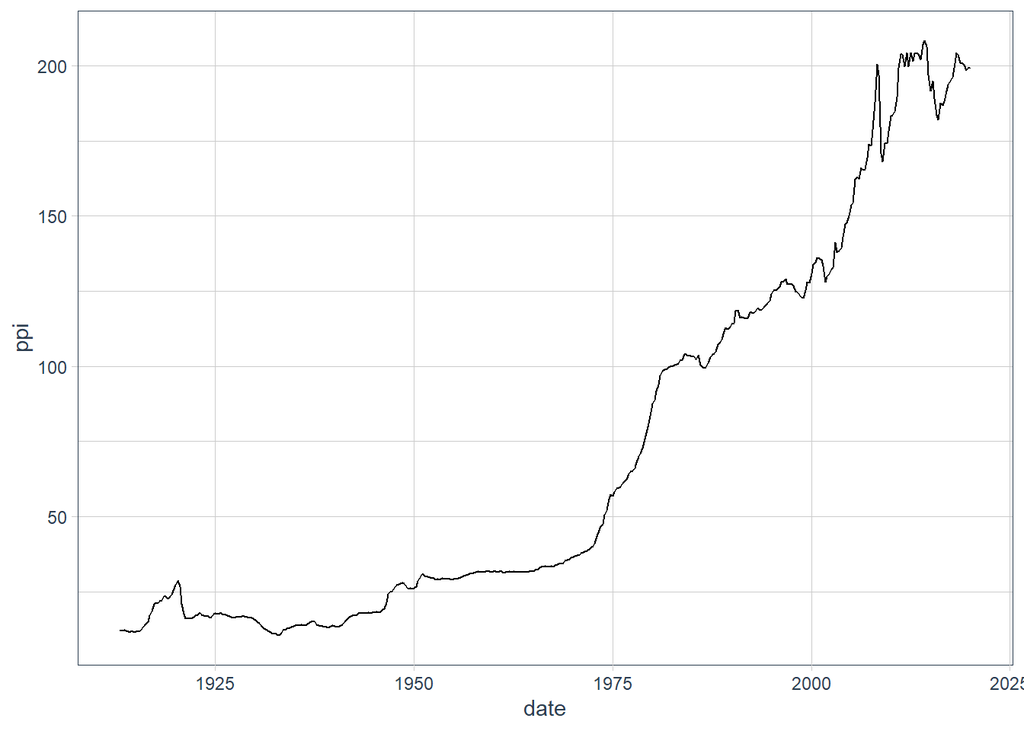

```r
ppi %>%
    ggplot(aes(x = date, y = ppi)) +
    geom_line() +
    #labs(title = title, y = y_label, x = x_label) +
    theme_tq()
```

## MACRO ECONOMIC FACTORS

### Gold

```r
ID = "GOLDAMGBD228NLBM"

gold = tqw_get_fred(ID = ID, from = from)
gold %>% glimpse()
```

```
## Observations: 13,539
## Variables: 2
## $ date  <date> 1968-04-01, 1968-04-02, 1968-04-03, 1968-04-04, 1968-04...
## $ price <dbl> 38.00, 37.60, 37.70, 36.70, 37.20, 37.00, 37.25, 37.60, ...
```

```r
gold = gold %>%
    tq_transmute(mutate_fun = to.period,
                 period = aggregate.period,
                 indexAt = index.at,
                 col_rename = "gold")
gold %>% glimpse()
```

```
## Observations: 208
## Variables: 2
## $ date <yearqtr> 1968 Q2, 1968 Q3, 1968 Q4, 1969 Q1, 1969 Q2, 1969 Q3,...
## $ gold <dbl> 40.950, 39.700, 41.950, 43.100, 41.225, 40.650, 35.210, 3...
```

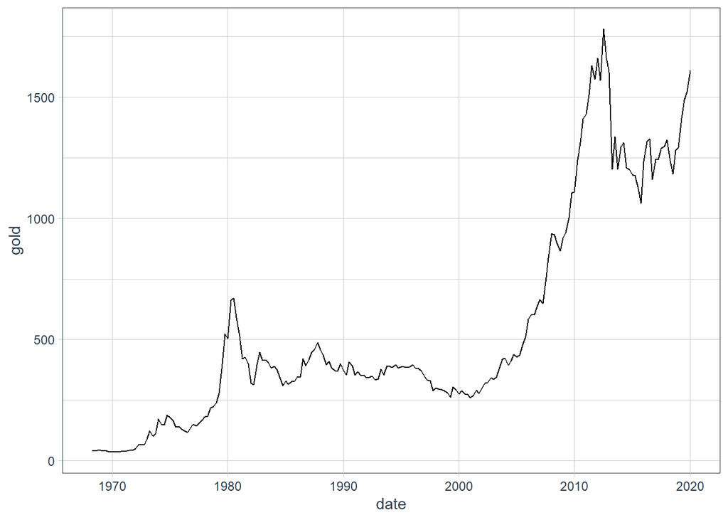

```r
gold %>%
    ggplot(aes(x = date, y = gold)) +
    geom_line() +
    #labs(title = title, y = y_label, x = x_label) +
    theme_tq()
```

### Exchange Rate

#### China

```r
ID = "EXCHUS"

china = tqw_get_fred(ID = ID, from = from)
china %>% glimpse()
```

```
## Observations: 469
## Variables: 2
## $ date  <date> 1981-01-01, 1981-02-01, 1981-03-01, 1981-04-01, 1981-05...
## $ price <dbl> 1.5518, 1.6131, 1.6314, 1.6660, 1.7270, 1.7605, 1.7647, ...
```

```r
china = china %>%
    tq_transmute(mutate_fun = to.period,
                 period = aggregate.period,
                 indexAt = index.at,
                 col_rename = "china")

china %>% glimpse()
```

```
## Observations: 157
## Variables: 2
## $ date  <yearqtr> 1981 Q1, 1981 Q2, 1981 Q3, 1981 Q4, 1982 Q1, 1982 Q2...
## $ china <dbl> 1.6314, 1.7605, 1.7542, 1.7405, 1.8429, 1.9014, 1.9567, ...
```

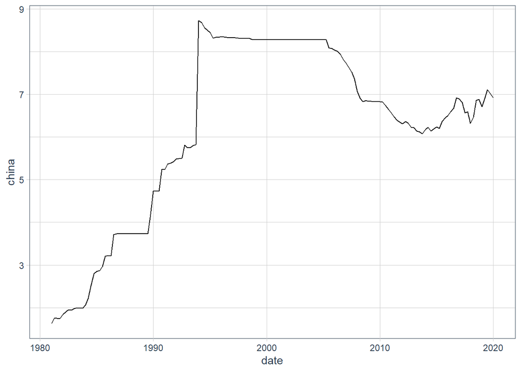

```r
china %>%
    ggplot(aes(x = date, y = china)) +
    geom_line() +
    #labs(title = title, y = y_label, x = x_label) +
    theme_tq()
```

#### Japan

```r
ID = "EXJPUS"

japan = tqw_get_fred(ID = ID, from = from)
japan %>% glimpse()
```

```
## Observations: 589
## Variables: 2
## $ date  <date> 1971-01-01, 1971-02-01, 1971-03-01, 1971-04-01, 1971-05...
## $ price <dbl> 358.0200, 357.5450, 357.5187, 357.5032, 357.4130, 357.41...
```

```r
japan = japan %>%
    tq_transmute(mutate_fun = to.period,
                 period = aggregate.period,
                 indexAt = index.at,
                 col_rename = "japan")

japan %>% glimpse()
```

```
## Observations: 197
## Variables: 2
## $ date  <yearqtr> 1971 Q1, 1971 Q2, 1971 Q3, 1971 Q4, 1972 Q1, 1972 Q2...
## $ japan <dbl> 357.5187, 357.4118, 338.0210, 320.0727, 302.5365, 302.41...
```

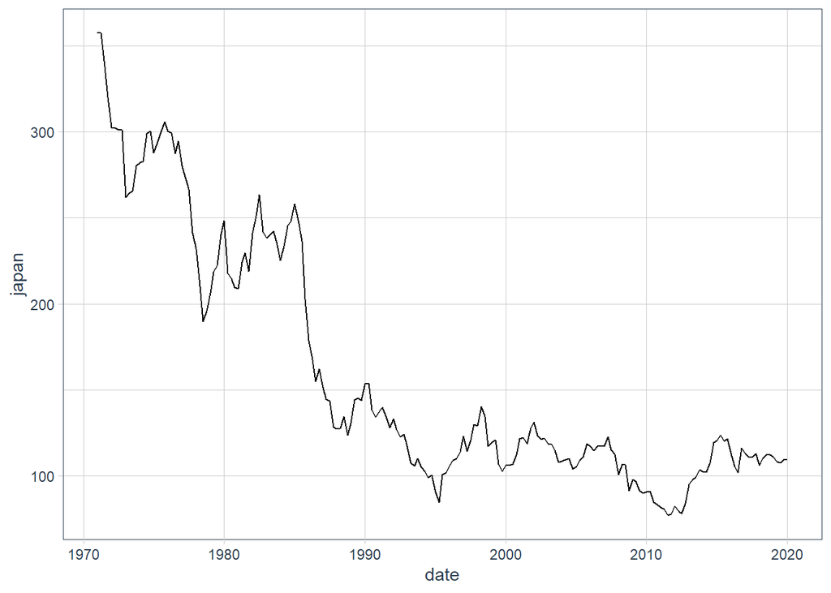

```r
japan %>%
    ggplot(aes(x = date, y = japan)) +
    geom_line() +
    #labs(title = title, y = y_label, x = x_label) +
    theme_tq()
```

#### UK

```r
ID = "EXUSUK"

uk = tqw_get_fred(ID = ID, from = from)
uk %>% glimpse()
```

```
## Observations: 589
## Variables: 2
## $ date  <date> 1971-01-01, 1971-02-01, 1971-03-01, 1971-04-01, 1971-05...
## $ price <dbl> 2.4058, 2.4178, 2.4187, 2.4179, 2.4187, 2.4188, 2.4185, ...
```

```r
uk = uk %>%
    tq_transmute(mutate_fun = to.period,
                 period = aggregate.period,
                 indexAt = index.at,
                 col_rename = "uk")

uk %>% glimpse()
```

```
## Observations: 197
## Variables: 2
## $ date <yearqtr> 1971 Q1, 1971 Q2, 1971 Q3, 1971 Q4, 1972 Q1, 1972 Q2,...
## $ uk   <dbl> 2.4187, 2.4188, 2.4694, 2.5266, 2.6181, 2.5691, 2.4410, 2...
```

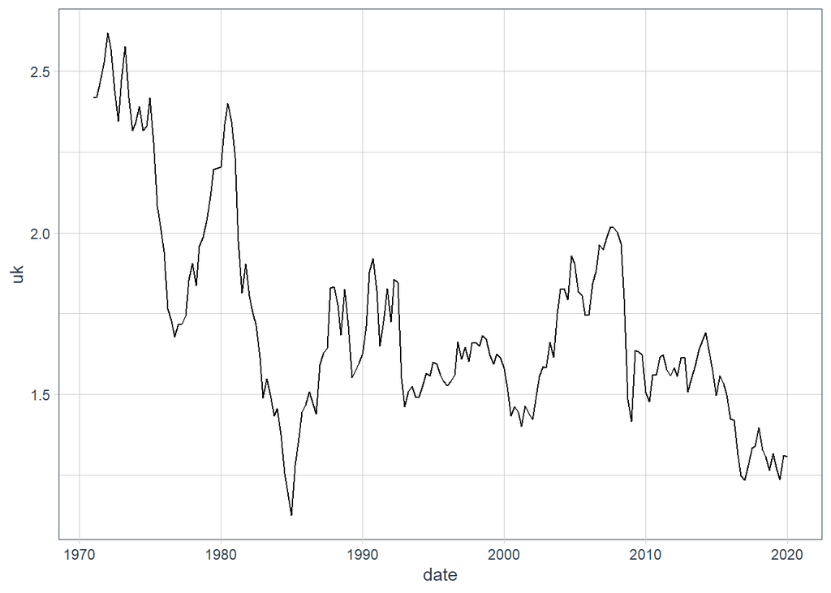

```r
uk %>%
    ggplot(aes(x = date, y = uk)) +
    geom_line() +
    #labs(title = title, y = y_label, x = x_label) +
    theme_tq()
```

# Merge Data

```r
dfs = list(gdp_change = gdp_change,
           labor_unrate = unrate,
           labor_nfjobs = nfjobs,
           monitory_treas10yr = treas10yr,
           # monitory_treas3mo = treas3mo,
           # monitory_treas10yr3mo = treas10yr3mo,
           monitory_fedintrate = fedintrate,
           # monitory_libor3mo = libor3mo,
           consumer_personincomechg = personincomechg,
           consumer_cpi = cpi,
           consumer_population = population,
           business_corpprofitchg = corpprofitchg,
           business_ccrude_wti = crude_wti,
           business_ppi = ppi,
           macro_gold = gold,
           macro_exc_japan = japan,
           # macro_exc_china = china,
           macro_exc_uk = uk
           )

for (i in 1:length(dfs)){
  print(paste0("Number of observations in ", names(dfs[i]), " = ", nrow(dfs[[i]])))
}
```

```
## [1] "Number of observations in gdp_change = 291"
## [1] "Number of observations in labor_unrate = 289"
## [1] "Number of observations in labor_nfjobs = 325"
## [1] "Number of observations in monitory_treas10yr = 233"
## [1] "Number of observations in monitory_fedintrate = 263"
## [1] "Number of observations in consumer_personincomechg = 288"
## [1] "Number of observations in consumer_cpi = 429"
## [1] "Number of observations in consumer_population = 244"
## [1] "Number of observations in business_corpprofitchg = 291"
## [1] "Number of observations in business_ccrude_wti = 297"
## [1] "Number of observations in business_ppi = 429"
## [1] "Number of observations in macro_gold = 208"
## [1] "Number of observations in macro_exc_japan = 197"
## [1] "Number of observations in macro_exc_uk = 197"
```

```r
# We may want to remove some of these variables if that is reducing the number of observations
# and is already highly correlated to other features. Example: libor3mo is related to fedintrate
```

```r
data = join_all(dfs, by='date', type='full') %>%
  arrange(date) %>%
  drop_na()

data %>% glimpse()
```

```
## Observations: 195
## Variables: 15
## $ date            <yearqtr> 1971 Q1, 1971 Q2, 1971 Q3, 1971 Q4, 1972 Q...
## $ gdp_change      <dbl> 18.2, 7.7, 7.6, 4.4, 14.3, 12.1, 7.9, 12.4, 15...
## $ unrate          <dbl> 6.0, 5.9, 6.0, 6.0, 5.8, 5.7, 5.5, 5.2, 4.9, 4...
## $ nfjobs          <int> 70860, 71254, 71614, 72109, 72944, 73758, 7426...
## $ treas10yr       <dbl> 5.53, 6.70, 6.00, 5.89, 6.12, 6.15, 6.54, 6.41...
## $ fedintrate      <dbl> 3.71, 4.91, 5.55, 4.14, 3.83, 4.46, 4.87, 5.33...
## $ personincomechg <dbl> 4.7, 4.9, 3.8, 5.2, 3.6, 3.2, 4.7, 7.6, 7.9, 7...
## $ cpi             <dbl> 40.0, 40.6, 40.8, 41.1, 41.4, 41.7, 42.1, 42.5...
## $ population      <int> 206960, 207562, 208230, 208829, 209299, 209811...
## $ corpprofitchg   <dbl> 12.7497657, 3.7704482, 6.6068568, 3.2925583, 5...
## $ crude_wti       <dbl> 3.56, 3.56, 3.56, 3.56, 3.56, 3.56, 3.56, 3.56...
## $ ppi             <dbl> 37.8, 38.2, 38.3, 38.6, 39.2, 39.7, 40.2, 41.1...
## $ gold            <dbl> 38.800, 40.200, 42.475, 43.500, 48.375, 64.100...
## $ japan           <dbl> 357.5187, 357.4118, 338.0210, 320.0727, 302.53...
## $ uk              <dbl> 2.4187, 2.4188, 2.4694, 2.5266, 2.6181, 2.5691...
```

```r
data %>% skim()
```

```
## Skim summary statistics
##  n obs: 195
##  n variables: 15
##
## -- Variable type:character ------------------------------------------------------------------------------------------------------------
##  variable missing complete   n min max empty n_unique
##      date       0      195 195   7   7     0      195
##
## -- Variable type:integer --------------------------------------------------------------------------------------------------------------
##    variable missing complete   n      mean       sd     p0    p25    p50
##      nfjobs       0      195 195 114043.25 23049.66  70860  91362 117286
##  population       0      195 195 267513.43 37700.35 206960 233955 266414
##     p75   p100     hist
##  132728 151368 ▅▃▃▅▂▅▇▃
##   3e+05 328897 ▇▇▇▅▅▆▆▇
##
## -- Variable type:numeric --------------------------------------------------------------------------------------------------------------
##         variable missing complete   n   mean     sd     p0    p25    p50
##    corpprofitchg       0      195 195   2.09   7.12 -41.16  -0.6    2.21
##              cpi       0      195 195 149.57  64.68  40     98.7  152.5
##        crude_wti       0      195 195  36.48  27.73   3.56  17.02  27.6
##       fedintrate       0      195 195   5.14   3.96   0.07   1.78   5.25
##       gdp_change       0      195 195   6.39   4.1   -7.2    4.2    5.7
##             gold       0      195 195 561.76 433.68  38.8  297.82 387.6
##            japan       0      195 195 159.3   72.35  76.8  107.64 122.6
##  personincomechg       0      195 195   2.95   1.85  -2.6    1.85   3.1
##              ppi       0      195 195 127.51  48.13  37.8  100    122.8
##        treas10yr       0      195 195   6.3    3.11   1.49   3.85   6.15
##               uk       0      195 195   1.72   0.32   1.13   1.51   1.63
##           unrate       0      195 195   6.24   1.6    3.5    5      5.9
##     p75    p100     hist
##    4.69   50.08 ▁▁▁▇▃▁▁▁
##  208.42  256.76 ▇▃▇▆▇▆▆▇
##   49.42  133.93 ▇▆▂▂▁▁▁▁
##    7.39   19.1  ▇▅▇▃▂▁▁▁
##    8      25.5  ▁▁▇▇▂▁▁▁
##  703.88 1781    ▂▇▁▁▁▂▁▁
##  220.68  357.52 ▇▇▁▁▃▂▂▁
##    3.95    7.9  ▁▁▂▆▇▃▁▁
##  170.1   208.3  ▃▃▃▇▆▂▃▇
##    8.03   15.84 ▇▆▇▇▃▂▂▁
##    1.85    2.62 ▁▃▇▃▂▁▂▁
##    7.3    10.8  ▃▆▇▃▅▂▂▁
```

```r
head(data)
```

```
##        date gdp_change unrate nfjobs treas10yr fedintrate personincomechg
## 233 1971 Q1       18.2    6.0  70860      5.53       3.71             4.7
## 234 1971 Q2        7.7    5.9  71254      6.70       4.91             4.9
## 235 1971 Q3        7.6    6.0  71614      6.00       5.55             3.8
## 236 1971 Q4        4.4    6.0  72109      5.89       4.14             5.2
## 237 1972 Q1       14.3    5.8  72944      6.12       3.83             3.6
## 238 1972 Q2       12.1    5.7  73758      6.15       4.46             3.2
##      cpi population corpprofitchg crude_wti  ppi   gold    japan     uk
## 233 40.0     206960     12.749766      3.56 37.8 38.800 357.5187 2.4187
## 234 40.6     207562      3.770448      3.56 38.2 40.200 357.4118 2.4188
## 235 40.8     208230      6.606857      3.56 38.3 42.475 338.0210 2.4694
## 236 41.1     208829      3.292558      3.56 38.6 43.500 320.0727 2.5266
## 237 41.4     209299      5.892195      3.56 39.2 48.375 302.5365 2.6181
## 238 41.7     209811      1.428866      3.56 39.7 64.100 302.4145 2.5691
```

```r
tail(data)
```

```
##        date gdp_change unrate nfjobs treas10yr fedintrate personincomechg
## 422 2018 Q2        7.1    4.0 148888      2.85       1.82             3.9
## 423 2018 Q3        4.8    3.7 149348      3.05       1.95             4.1
## 424 2018 Q4        2.9    3.9 149865      2.69       2.27             3.9
## 425 2019 Q1        3.9    3.8 150282      2.41       2.41             3.3
## 426 2019 Q2        4.7    3.7 150759      2.00       2.38             3.0
## 427 2019 Q3        3.8    3.5 151368      1.68       2.04             2.9
##         cpi population corpprofitchg crude_wti   ppi    gold    japan
## 422 251.989     326847     0.9507799     67.87 204.2 1250.55 110.0638
## 423 252.439     327328     0.1634533     70.23 203.6 1183.50 112.0974
## 424 251.233     327722    -1.5463943     49.52 201.0 1281.65 112.1994
## 425 254.202     328025    -1.5322271     58.15 200.8 1291.15 111.1443
## 426 256.143     328404     3.3161893     54.66 200.3 1413.20 108.0685
## 427 256.759     328897    -1.2422698     56.95 198.4 1487.60 107.5400
##         uk
## 422 1.3294
## 423 1.3066
## 424 1.2664
## 425 1.3167
## 426 1.2675
## 427 1.2369
```

- But wait. We need to predict the GDP in the future quarters using data available in this quarter.
- So we may need to change the gdp column to a lagged gdp column (for next quarter). We will evaluate how to do this.

```r
write.csv(data, "economic_indicators_all_ex_3mo_china.csv", row.names = FALSE)
```

# TODO

## Questions for Dr. Sadler

1. Why is ARIMA prediction jumping like that at the beginning
2. Some data is quarterly and some if monthly. How do we not lose the monthly granularity and still use the quarterly data? Is this still possible, since our output (GDP) is measured quarterly, i.e. our can we predict quarterly data using monthly frequency of certain variables?
3. If we expect certain predictors to themselves be non-stationary (such as $ corporate profits), should we convert this to a stationary signal such as % change from las period?
4. When collecting the data (predictors), some are seasonally adjusted and some are not. If we have a choice, which one should we pick? Does it matter?

## Things to Consider

1. Consider removing the data related to the 3mo Treasury Rate (since it only has 137 quarterly observations) and China Exchange Rate (it only has < 160 quarterly observations and also this data was controlled artificially for a while). If we remove these we can increase our dataset to close to 200 observations (almost 50% increase).

## Data Collection

1. See if the value used during the resampling can be converted to the median value during that period.
- https://cran.r-project.org/web/packages/tidyquant/vignettes/TQ02-quant-integrations-in-tidyquant.html#example-2-use-xts-to.period-to-change-the-periodicity-from-daily-to-monthly

```
unrate2 = unrate %>%
    tq_transmute(mutate_fun = apply.quarterly,
                 indexAt = index.at,
                 FUN = median,
                 col_rename = "unrate") %>%
    mutate(date = paste0(year(date), " Q", quarter(date)))
# Need to convert date to type 'datetime'

unrate2 %>% glimpse()
```

## EDA

1. Plot correlation plots with lagged variables to gain insight into what features might be useful predictors.

## Model Analysis

1. If I take GDP data from way back (1946), the resultsfor ARMA and ARIMA analysis are very different (spectral densities, etc). So, while fitting, should we not do something like 5 fold cross validation?
2. Use Rolling Window to calculate the ASE inistead of just the last n values. This will give a more robust estimate.